[figure not shown]

# 1. Objective

# BankBoostX

### Empowering Banking Success

- This study's goal is to evaluate and forecast the results of direct marketing campaigns run by a Portuguese banking institution. These campaigns involved calling clients to see if they would sign up for a term deposit with the bank. Predicting whether a customer will choose to subscribe to a term deposit is the main objective, with the ultimate goal of optimizing the bank's marketing tactics. The dataset used in this study spans the months of May 2008 and November 2010, contains 41,188 examples, and uses 20 input variables.
- BankBoostX, the company in charge of carrying out the previously mentioned direct marketing campaigns, will probably be the project's main stakeholder. The findings of this study will help the bank make more informed choices regarding the best use of its marketing resources. The bank can change its marketing strategy to target the right customers at the right time, increasing the success of the campaigns, by gaining insight into the factors that affect a customer's decision to open a fixed deposit. The bank would ultimately profit from increased customer engagement, higher order prices, and more effective resource allocation.
- Researchers, decision-makers in government, and specialists in marketing and data could all benefit from the study. The results of this study can be used by them to improve their understanding of consumer behavior, develop better marketing strategies, and make data-driven decisions in their line of work. Overall, the project's findings may contribute to the improvement of direct marketing campaigns in the banking sector and other related industries, which would be great for the bank as well as the larger marketing and customer engagement community.

# 2. Data Exploration

```python
# import the necessary libraries
import pandas as pd
import numpy as np
import matplotlib.pyplot as plt
import seaborn as sns
from scipy.cluster.hierarchy import fcluster, linkage
from scipy.cluster.hierarchy import dendrogram, linkage
from collections import Counter
from sklearn.neighbors import KNeighborsClassifier
from sklearn.preprocessing import LabelEncoder
import warnings
warnings.filterwarnings("ignore")
```

```python
# loading the dataset into a dataframe
df = pd.read_csv('/content/bank-additional-full.csv', sep=';')
```

```python
# printing the first five rows
df.head()
```

|  | age | job | marital | education | default | housing | loan | contact | month | day_of_week | ... | campaign | pdays | previous | poutcome | emp.var.rate | cons.price.idx | cons.conf.idx | euribor3m | nr.employed | y |
| --- | --- | --- | --- | --- | --- | --- | --- | --- | --- | --- | --- | --- | --- | --- | --- | --- | --- | --- | --- | --- | --- |
| 0 | 56 | housemaid | married | basic.4y | no | no | no | telephone | may | mon | ... | 1 | 999 | 0 | nonexistent | 1.1 | 93.994 | -36.4 | 4.857 | 5191.0 | no |
| 1 | 57 | services | married | high.school | unknown | no | no | telephone | may | mon | ... | 1 | 999 | 0 | nonexistent | 1.1 | 93.994 | -36.4 | 4.857 | 5191.0 | no |
| 2 | 37 | services | married | high.school | no | yes | no | telephone | may | mon | ... | 1 | 999 | 0 | nonexistent | 1.1 | 93.994 | -36.4 | 4.857 | 5191.0 | no |
| 3 | 40 | admin. | married | basic.6y | no | no | no | telephone | may | mon | ... | 1 | 999 | 0 | nonexistent | 1.1 | 93.994 | -36.4 | 4.857 | 5191.0 | no |
| 4 | 56 | services | married | high.school | no | no | yes | telephone | may | mon | ... | 1 | 999 | 0 | nonexistent | 1.1 | 93.994 | -36.4 | 4.857 | 5191.0 | no |

5 rows × 21 columns

```python
# printing the rows and columns of the dataframe
df.shape
```

```
(41188, 21)
```

```python
# subsetting the dataframe as the data is too big (41,188 rows)
seed = 44
df = df.sample(frac = 0.2, random_state = seed)
df.head()
```

|  | age | job | marital | education | default | housing | loan | contact | month | day_of_week | ... | campaign | pdays | previous | poutcome | emp.var.rate | cons.price.idx | cons.conf.idx | euribor3m | nr.employed | y |
| --- | --- | --- | --- | --- | --- | --- | --- | --- | --- | --- | --- | --- | --- | --- | --- | --- | --- | --- | --- | --- | --- |
| 4882 | 42 | self-employed | married | university.degree | no | no | no | telephone | may | wed | ... | 2 | 999 | 0 | nonexistent | 1.1 | 93.994 | -36.4 | 4.858 | 5191.0 | no |
| 13155 | 33 | self-employed | married | university.degree | no | yes | no | cellular | jul | wed | ... | 2 | 999 | 0 | nonexistent | 1.4 | 93.918 | -42.7 | 4.962 | 5228.1 | no |
| 27566 | 54 | admin. | divorced | high.school | no | no | no | cellular | nov | fri | ... | 2 | 999 | 1 | failure | -0.1 | 93.200 | -42.0 | 4.021 | 5195.8 | no |
| 18195 | 36 | technician | married | high.school | no | no | no | cellular | jul | wed | ... | 4 | 999 | 0 | nonexistent | 1.4 | 93.918 | -42.7 | 4.963 | 5228.1 | no |
| 8027 | 33 | admin. | married | high.school | no | yes | no | telephone | jun | mon | ... | 3 | 999 | 0 | nonexistent | 1.4 | 94.465 | -41.8 | 4.865 | 5228.1 | no |

5 rows × 21 columns

```python
# printing the information about the data
df.info()
```

```
<class 'pandas.core.frame.DataFrame'>
Int64Index: 8238 entries, 4882 to 15078
Data columns (total 21 columns):
 #   Column          Non-Null Count  Dtype
---  ------          --------------  -----
 0   age             8238 non-null   int64
 1   job             8238 non-null   object
 2   marital         8238 non-null   object
 3   education       8238 non-null   object
 4   default         8238 non-null   object
 5   housing         8238 non-null   object
 6   loan            8238 non-null   object
 7   contact         8238 non-null   object
 8   month           8238 non-null   object
 9   day_of_week     8238 non-null   object
 10  duration        8238 non-null   int64
 11  campaign        8238 non-null   int64
 12  pdays           8238 non-null   int64
 13  previous        8238 non-null   int64
 14  poutcome        8238 non-null   object
 15  emp.var.rate    8238 non-null   float64
 16  cons.price.idx  8238 non-null   float64
 17  cons.conf.idx   8238 non-null   float64
 18  euribor3m       8238 non-null   float64
 19  nr.employed     8238 non-null   float64
 20  y               8238 non-null   object
dtypes: float64(5), int64(5), object(11)
memory usage: 1.4+ MB
```

```python
# printing the description of the data
df.describe()
```

|  | age | duration | campaign | pdays | previous | emp.var.rate | cons.price.idx | cons.conf.idx | euribor3m | nr.employed |
| --- | --- | --- | --- | --- | --- | --- | --- | --- | --- | --- |
| count | 8238.000000 | 8238.000000 | 8238.000000 | 8238.000000 | 8238.000000 | 8238.000000 | 8238.000000 | 8238.000000 | 8238.000000 | 8238.000000 |
| mean | 39.958121 | 259.705875 | 2.553775 | 963.075140 | 0.164118 | 0.054625 | 93.560426 | -40.396892 | 3.599559 | 5166.264118 |
| std | 10.341085 | 261.641638 | 2.702605 | 185.450128 | 0.475465 | 1.592300 | 0.579707 | 4.680495 | 1.744775 | 72.826169 |
| min | 17.000000 | 4.000000 | 1.000000 | 0.000000 | 0.000000 | -3.400000 | 92.201000 | -50.800000 | 0.635000 | 4963.600000 |
| 25% | 32.000000 | 101.000000 | 1.000000 | 999.000000 | 0.000000 | -1.800000 | 93.075000 | -42.700000 | 1.334000 | 5099.100000 |
| 50% | 38.000000 | 181.000000 | 2.000000 | 999.000000 | 0.000000 | 1.100000 | 93.444000 | -41.800000 | 4.857000 | 5191.000000 |
| 75% | 47.000000 | 324.000000 | 3.000000 | 999.000000 | 0.000000 | 1.400000 | 93.994000 | -36.400000 | 4.961000 | 5228.100000 |
| max | 92.000000 | 3322.000000 | 43.000000 | 999.000000 | 6.000000 | 1.400000 | 94.767000 | -26.900000 | 5.045000 | 5228.100000 |

```python
# printing all the unique value of the column job
df['job'].unique()
```

```
array(['self-employed', 'admin.', 'technician', 'student', 'unemployed',
       'services', 'blue-collar', 'management', 'housemaid', 'retired',
       'entrepreneur', 'unknown'], dtype=object)
```

```python
# printing the count of each kind of value for the column 'marital'
df['marital'].value_counts()
```

```
married     5002
single      2331
divorced     885
unknown       20
Name: marital, dtype: int64
```

```python
# printing the correlation between each column
df.corr()
```

|  | age | duration | campaign | pdays | previous | emp.var.rate | cons.price.idx | cons.conf.idx | euribor3m | nr.employed |
| --- | --- | --- | --- | --- | --- | --- | --- | --- | --- | --- |
| age | 1.000000 | -0.009762 | -0.001138 | -0.044406 | 0.014435 | 0.008127 | -0.008449 | 0.143801 | 0.025644 | 0.003972 |
| duration | -0.009762 | 1.000000 | -0.090488 | -0.054984 | 0.034061 | -0.036541 | -0.003956 | -0.004013 | -0.040569 | -0.051050 |
| campaign | -0.001138 | -0.090488 | 1.000000 | 0.051003 | -0.072437 | 0.155134 | 0.132127 | -0.022823 | 0.143016 | 0.153840 |
| pdays | -0.044406 | -0.054984 | 0.051003 | 1.000000 | -0.560798 | 0.276711 | 0.115845 | -0.115047 | 0.292007 | 0.348675 |
| previous | 0.014435 | 0.034061 | -0.072437 | -0.560798 | 1.000000 | -0.417562 | -0.218735 | -0.009247 | -0.444678 | -0.485149 |
| emp.var.rate | 0.008127 | -0.036541 | 0.155134 | 0.276711 | -0.417562 | 1.000000 | 0.778627 | 0.158165 | 0.971909 | 0.910811 |
| cons.price.idx | -0.008449 | -0.003956 | 0.132127 | 0.115845 | -0.218735 | 0.778627 | 1.000000 | 0.032521 | 0.693025 | 0.534615 |
| cons.conf.idx | 0.143801 | -0.004013 | -0.022823 | -0.115047 | -0.009247 | 0.158165 | 0.032521 | 1.000000 | 0.242266 | 0.062728 |
| euribor3m | 0.025644 | -0.040569 | 0.143016 | 0.292007 | -0.444678 | 0.971909 | 0.693025 | 0.242266 | 1.000000 | 0.947168 |
| nr.employed | 0.003972 | -0.051050 | 0.153840 | 0.348675 | -0.485149 | 0.910811 | 0.534615 | 0.062728 | 0.947168 | 1.000000 |

#### Plotting correlation matrix to understand the correlation between all the features.

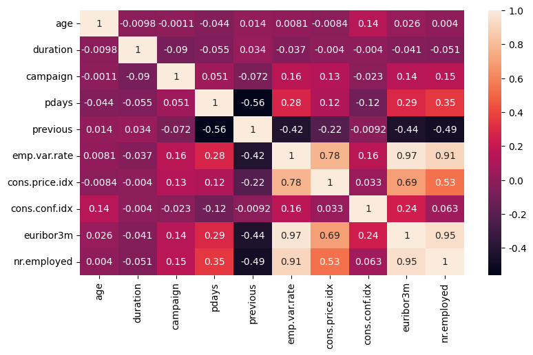

```python
# correlation matrix
df.corr()
plt.figure(figsize=(9, 5))
plt.rcParams['axes.unicode_minus'] = False
sns.heatmap(df.corr(), annot = True)
```

#### Plotting a histogram to understand the distribution of ages.

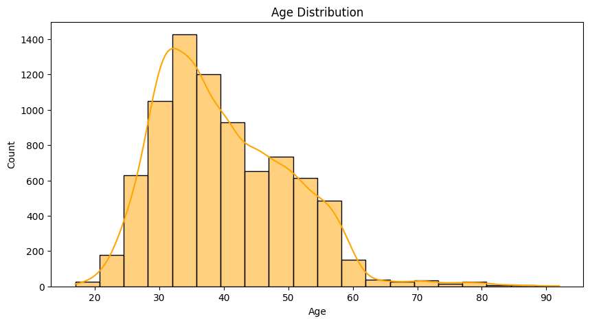

```python
# histogram of the column 'ages'
plt.figure(figsize = (10, 5))
sns.histplot(df['age'], bins = 20, kde = True, color = 'orange')
plt.title('Age Distribution')
plt.xlabel('Age')
plt.ylabel('Count')
plt.show()
```

#### Plotting the distribution for number of employees for each job

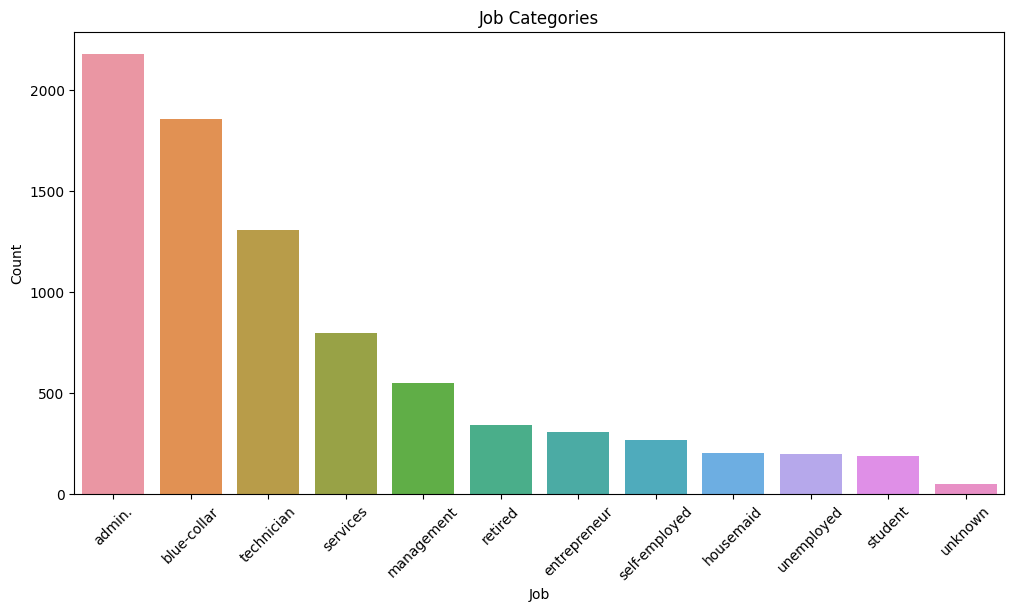

```python
# bar plot of the column 'job'
job_counts = df['job'].value_counts()
plt.figure(figsize = (12, 6))
sns.barplot(x = job_counts.index, y = job_counts.values)
plt.title('Job Categories')
plt.xlabel('Job')
plt.ylabel('Count')
plt.xticks(rotation = 45)
plt.show()
```

#### Plotting the distribution for all marital statuses

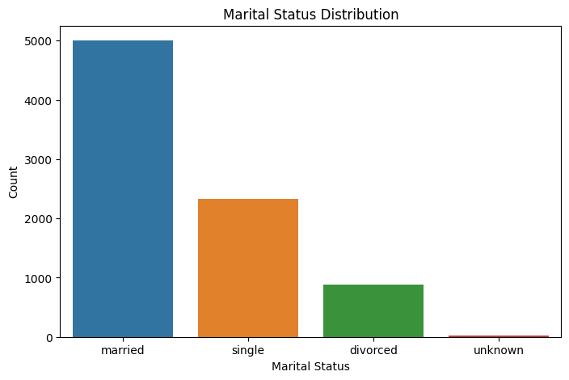

```python
# bar plot of the column 'marital'
marital_counts = df['marital'].value_counts()
plt.figure(figsize = (8, 5))
sns.barplot(x = marital_counts.index, y = marital_counts.values)
plt.title('Marital Status Distribution')
plt.xlabel('Marital Status')
plt.ylabel('Count')
plt.show()
```

Plotting histograms for all the columns to understand the data in detail to find patterns on a deeper level.

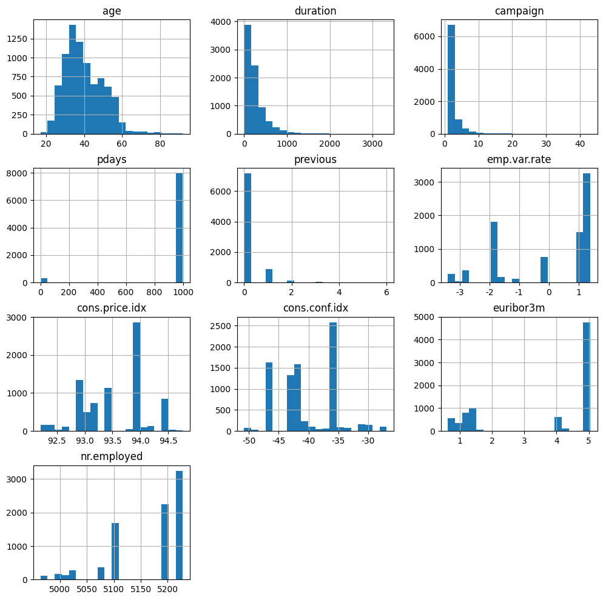

```python
# histograms of all the numerical columns
df.hist(figsize = (12, 12), bins=20)
plt.show()
```

# 3. Data Cleaning

Deleting the column 'loan' as there are no such relationships found with it

```python
df = df.drop(['loan'], axis = 1)
```

Deleting the column 'contact' as there is very less correlation with all the other features in the dataframe

```python
df = df.drop(['contact'], axis = 1)
```

# 4. Adaptation

#### Different categories for the column 'Age Groups' as Young, Middle-Aged & Senior and 'duration' as Short, Medium and Long.

```python
# categorizing the column 'Age Groups' based on age bins and labels
age_bins = [18, 30, 50, 100]
age_labels = ['Young', 'Middle-Aged', 'Senior']
df['Age Groups'] = pd.cut(df['age'], bins = age_bins, labels = age_labels, include_lowest = True)

# categorizing the column 'duration' based on age bins and labels
duration_bins = [0, 180, 300, df['duration'].max()]
duration_labels = ['Short', 'Medium', 'Long']
df['Contact Duration Categories'] = pd.cut(df['duration'], bins = duration_bins, labels = duration_labels, include_lowest = True)
df.head()
```

|  | age | job | marital | education | default | housing | month | day_of_week | duration | campaign | ... | previous | poutcome | emp.var.rate | cons.price.idx | cons.conf.idx | euribor3m | nr.employed | y | Age Groups | Contact Duration Categories |
| --- | --- | --- | --- | --- | --- | --- | --- | --- | --- | --- | --- | --- | --- | --- | --- | --- | --- | --- | --- | --- | --- |
| 4882 | 42 | self-employed | married | university.degree | no | no | may | wed | 518 | 2 | ... | 0 | nonexistent | 1.1 | 93.994 | -36.4 | 4.858 | 5191.0 | no | Middle-Aged | Long |
| 13155 | 33 | self-employed | married | university.degree | no | yes | jul | wed | 99 | 2 | ... | 0 | nonexistent | 1.4 | 93.918 | -42.7 | 4.962 | 5228.1 | no | Middle-Aged | Short |
| 27566 | 54 | admin. | divorced | high.school | no | no | nov | fri | 639 | 2 | ... | 1 | failure | -0.1 | 93.200 | -42.0 | 4.021 | 5195.8 | no | Senior | Long |
| 18195 | 36 | technician | married | high.school | no | no | jul | wed | 1165 | 4 | ... | 0 | nonexistent | 1.4 | 93.918 | -42.7 | 4.963 | 5228.1 | no | Middle-Aged | Long |
| 8027 | 33 | admin. | married | high.school | no | yes | jun | mon | 111 | 3 | ... | 0 | nonexistent | 1.4 | 94.465 | -41.8 | 4.865 | 5228.1 | no | Middle-Aged | Short |

5 rows × 21 columns

```python
# printing the last 15 rows of the dataframe
df.tail(15)
```

|  | age | job | marital | education | default | housing | month | day_of_week | duration | campaign | ... | previous | poutcome | emp.var.rate | cons.price.idx | cons.conf.idx | euribor3m | nr.employed | y | Age Groups | Contact Duration Categories |
| --- | --- | --- | --- | --- | --- | --- | --- | --- | --- | --- | --- | --- | --- | --- | --- | --- | --- | --- | --- | --- | --- |
| 37899 | 28 | management | single | university.degree | no | yes | sep | tue | 76 | 1 | ... | 0 | nonexistent | -3.4 | 92.379 | -29.8 | 0.819 | 5017.5 | no | Young | Short |
| 37422 | 36 | admin. | single | university.degree | no | yes | aug | wed | 87 | 1 | ... | 2 | failure | -2.9 | 92.201 | -31.4 | 0.879 | 5076.2 | no | Middle-Aged | Short |
| 18443 | 36 | technician | married | high.school | no | no | jul | thu | 110 | 6 | ... | 0 | nonexistent | 1.4 | 93.918 | -42.7 | 4.968 | 5228.1 | no | Middle-Aged | Short |
| 1147 | 37 | technician | married | professional.course | no | yes | may | thu | 238 | 3 | ... | 0 | nonexistent | 1.1 | 93.994 | -36.4 | 4.855 | 5191.0 | no | Middle-Aged | Medium |
| 30398 | 32 | blue-collar | married | professional.course | unknown | yes | apr | thu | 73 | 2 | ... | 1 | failure | -1.8 | 93.075 | -47.1 | 1.365 | 5099.1 | no | Middle-Aged | Short |
| 13783 | 46 | blue-collar | married | basic.4y | unknown | yes | jul | thu | 118 | 1 | ... | 0 | nonexistent | 1.4 | 93.918 | -42.7 | 4.963 | 5228.1 | no | Middle-Aged | Short |
| 19545 | 39 | admin. | single | high.school | no | yes | aug | thu | 73 | 1 | ... | 0 | nonexistent | 1.4 | 93.444 | -36.1 | 4.968 | 5228.1 | no | Middle-Aged | Short |
| 3440 | 43 | admin. | married | university.degree | unknown | yes | may | thu | 17 | 10 | ... | 0 | nonexistent | 1.1 | 93.994 | -36.4 | 4.860 | 5191.0 | no | Middle-Aged | Short |
| 969 | 33 | admin. | married | university.degree | no | no | may | wed | 55 | 1 | ... | 0 | nonexistent | 1.1 | 93.994 | -36.4 | 4.856 | 5191.0 | no | Middle-Aged | Short |
| 28644 | 38 | blue-collar | married | basic.4y | unknown | yes | apr | thu | 258 | 1 | ... | 1 | failure | -1.8 | 93.075 | -47.1 | 1.410 | 5099.1 | no | Middle-Aged | Medium |
| 32120 | 45 | technician | divorced | university.degree | unknown | yes | may | fri | 84 | 1 | ... | 1 | failure | -1.8 | 92.893 | -46.2 | 1.313 | 5099.1 | no | Middle-Aged | Short |
| 2359 | 45 | blue-collar | married | basic.4y | no | no | may | tue | 44 | 1 | ... | 0 | nonexistent | 1.1 | 93.994 | -36.4 | 4.856 | 5191.0 | no | Middle-Aged | Short |
| 21251 | 33 | management | married | university.degree | no | yes | aug | mon | 128 | 1 | ... | 0 | nonexistent | 1.4 | 93.444 | -36.1 | 4.963 | 5228.1 | no | Middle-Aged | Short |
| 21675 | 32 | admin. | single | university.degree | no | yes | aug | tue | 220 | 1 | ... | 0 | nonexistent | 1.4 | 93.444 | -36.1 | 4.963 | 5228.1 | no | Middle-Aged | Medium |
| 15078 | 41 | entrepreneur | married | professional.course | no | yes | jul | thu | 156 | 1 | ... | 0 | nonexistent | 1.4 | 93.918 | -42.7 | 4.958 | 5228.1 | no | Middle-Aged | Short |

15 rows × 21 columns

```python
# created a column 'y_binary' of binary values of the column 'y'
df['y_binary'] = df['y'].apply(lambda x: 1 if x == 'yes' else 0)
df.head(25)
```

|  | age | job | marital | education | default | housing | month | day_of_week | duration | campaign | ... | poutcome | emp.var.rate | cons.price.idx | cons.conf.idx | euribor3m | nr.employed | y | Age Groups | Contact Duration Categories | y_binary |
| --- | --- | --- | --- | --- | --- | --- | --- | --- | --- | --- | --- | --- | --- | --- | --- | --- | --- | --- | --- | --- | --- |
| 4882 | 42 | self-employed | married | university.degree | no | no | may | wed | 518 | 2 | ... | nonexistent | 1.1 | 93.994 | -36.4 | 4.858 | 5191.0 | no | Middle-Aged | Long | 0 |
| 13155 | 33 | self-employed | married | university.degree | no | yes | jul | wed | 99 | 2 | ... | nonexistent | 1.4 | 93.918 | -42.7 | 4.962 | 5228.1 | no | Middle-Aged | Short | 0 |
| 27566 | 54 | admin. | divorced | high.school | no | no | nov | fri | 639 | 2 | ... | failure | -0.1 | 93.200 | -42.0 | 4.021 | 5195.8 | no | Senior | Long | 0 |
| 18195 | 36 | technician | married | high.school | no | no | jul | wed | 1165 | 4 | ... | nonexistent | 1.4 | 93.918 | -42.7 | 4.963 | 5228.1 | no | Middle-Aged | Long | 0 |
| 8027 | 33 | admin. | married | high.school | no | yes | jun | mon | 111 | 3 | ... | nonexistent | 1.4 | 94.465 | -41.8 | 4.865 | 5228.1 | no | Middle-Aged | Short | 0 |
| 34314 | 26 | student | single | unknown | no | yes | may | thu | 306 | 1 | ... | nonexistent | -1.8 | 92.893 | -46.2 | 1.266 | 5099.1 | no | Young | Long | 0 |
| 25485 | 36 | technician | married | university.degree | no | no | nov | wed | 221 | 4 | ... | nonexistent | -0.1 | 93.200 | -42.0 | 4.120 | 5195.8 | no | Middle-Aged | Medium | 0 |
| 37752 | 34 | unemployed | single | professional.course | no | no | aug | fri | 531 | 2 | ... | success | -2.9 | 92.201 | -31.4 | 0.849 | 5076.2 | yes | Middle-Aged | Long | 1 |
| 6822 | 25 | services | married | high.school | no | yes | may | wed | 452 | 2 | ... | nonexistent | 1.1 | 93.994 | -36.4 | 4.857 | 5191.0 | no | Young | Long | 0 |
| 19375 | 36 | self-employed | married | basic.4y | unknown | yes | aug | wed | 175 | 4 | ... | nonexistent | 1.4 | 93.444 | -36.1 | 4.967 | 5228.1 | no | Middle-Aged | Short | 0 |
| 14963 | 24 | blue-collar | married | basic.9y | no | no | jul | wed | 255 | 2 | ... | nonexistent | 1.4 | 93.918 | -42.7 | 4.957 | 5228.1 | no | Young | Medium | 0 |
| 8246 | 48 | management | married | university.degree | no | yes | jun | tue | 1025 | 7 | ... | nonexistent | 1.4 | 94.465 | -41.8 | 4.864 | 5228.1 | yes | Middle-Aged | Long | 1 |
| 15409 | 22 | blue-collar | single | basic.9y | no | no | jul | fri | 106 | 1 | ... | nonexistent | 1.4 | 93.918 | -42.7 | 4.957 | 5228.1 | no | Young | Short | 0 |
| 18878 | 39 | housemaid | married | basic.4y | no | yes | aug | mon | 417 | 1 | ... | nonexistent | 1.4 | 93.444 | -36.1 | 4.970 | 5228.1 | no | Middle-Aged | Long | 0 |
| 1516 | 40 | admin. | married | university.degree | unknown | yes | may | thu | 91 | 3 | ... | nonexistent | 1.1 | 93.994 | -36.4 | 4.855 | 5191.0 | no | Middle-Aged | Short | 0 |
| 19086 | 53 | blue-collar | married | basic.9y | no | yes | aug | tue | 334 | 2 | ... | nonexistent | 1.4 | 93.444 | -36.1 | 4.968 | 5228.1 | no | Senior | Long | 0 |
| 36714 | 27 | admin. | single | university.degree | no | no | jun | fri | 96 | 2 | ... | nonexistent | -2.9 | 92.963 | -40.8 | 1.268 | 5076.2 | no | Young | Short | 0 |
| 22243 | 38 | technician | married | professional.course | unknown | no | aug | thu | 318 | 3 | ... | nonexistent | 1.4 | 93.444 | -36.1 | 4.963 | 5228.1 | no | Middle-Aged | Long | 0 |
| 10587 | 36 | unemployed | married | high.school | no | yes | jun | tue | 652 | 2 | ... | nonexistent | 1.4 | 94.465 | -41.8 | 4.961 | 5228.1 | no | Middle-Aged | Long | 0 |
| 16569 | 37 | technician | single | university.degree | no | yes | jul | wed | 256 | 1 | ... | nonexistent | 1.4 | 93.918 | -42.7 | 4.963 | 5228.1 | no | Middle-Aged | Medium | 0 |
| 3481 | 46 | admin. | single | high.school | no | no | may | thu | 78 | 4 | ... | nonexistent | 1.1 | 93.994 | -36.4 | 4.860 | 5191.0 | no | Middle-Aged | Short | 0 |
| 30082 | 27 | student | single | university.degree | no | no | apr | fri | 227 | 1 | ... | failure | -1.8 | 93.075 | -47.1 | 1.400 | 5099.1 | yes | Young | Medium | 1 |
| 8070 | 54 | blue-collar | married | high.school | no | no | jun | mon | 53 | 1 | ... | nonexistent | 1.4 | 94.465 | -41.8 | 4.865 | 5228.1 | no | Senior | Short | 0 |
| 25433 | 29 | management | single | university.degree | no | no | nov | wed | 62 | 1 | ... | nonexistent | -0.1 | 93.200 | -42.0 | 4.120 | 5195.8 | no | Young | Short | 0 |
| 31043 | 31 | blue-collar | single | basic.9y | unknown | yes | may | wed | 55 | 2 | ... | nonexistent | -1.8 | 92.893 | -46.2 | 1.334 | 5099.1 | no | Middle-Aged | Short | 0 |

25 rows × 22 columns

#### Plotting the distribution of the column 'Age Groups' which have 3 distinct values, Young, Middle-Aged and Senior.

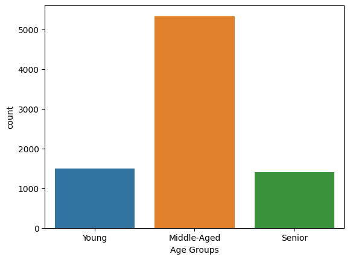

```python
# plot of the column 'Age Groups'
sns.countplot(x = 'Age Groups', data = df)
plt.show()
```

# 5. Descriptive Visualization

#### 1. This code generates a stacked bar chart using data from the 'education' and 'y' columns of a DataFrame (df).The chart displays how many 'yes' and 'no' outcomes are related to each education level, with each level represented as a separate bar. This visualization provides a quick overview of how education influences the target variable, making it easier to identify patterns or trends in the data.

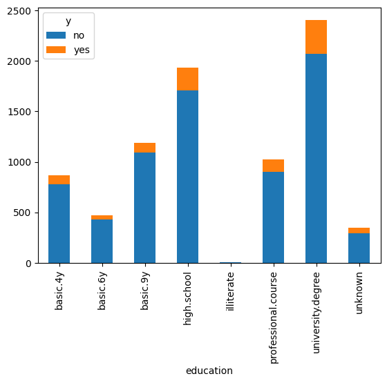

```python
pd.crosstab(df['education'], df['y']).plot(kind = 'bar', stacked = True)
plt.show()
```

#### 2. The given code produces a heatmap show by utilizing a rotate table from a DataFrame (df) to organize information concurring to 'Contact Length Categories' and 'previous' factors while counting the occurrences of 'y.' The resulting heatmap an be used to spot trends and connections between contact length, prior contacts, and the target variable "y." This visual representation is instrumental in comprehending the interplay between these factors and their influence on the outcome.

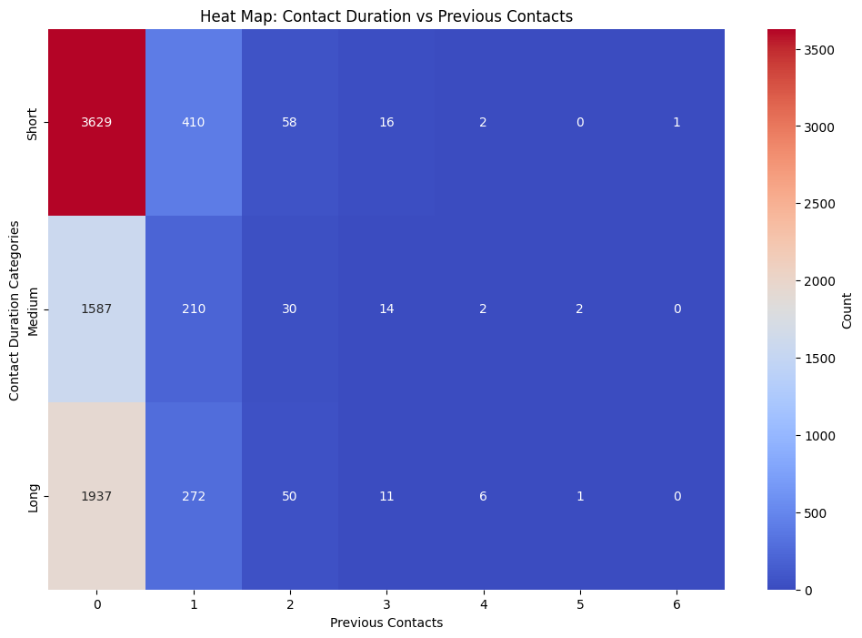

```python
pivot_table = df.pivot_table(index = 'Contact Duration Categories', columns = 'previous', values = 'y', aggfunc = 'count')

plt.figure(figsize = (12, 8))
sns.heatmap(pivot_table, annot = True, fmt = 'd', cmap = 'coolwarm', cbar_kws = {'label': 'Count'})
plt.title('Heat Map: Contact Duration vs Previous Contacts')
plt.xlabel('Previous Contacts')
plt.ylabel('Contact Duration Categories')
plt.show()
```

#### 3. In this code, the distribution of ages in a dataset is visualized using a Kernel Density Estimation (KDE) plot made with Seaborn (sns). For those who subscribed (labeled "Subscribed") and those who did not (labeled "Not Subscribed"), two KDE charts are shown. The estimated probability density is represented by the shaded areas underneath each curve, making it easy to compare the age distributions of subscribers and non-subscribers. Potential age-related patterns in subscription behavior can be found using this visualization.

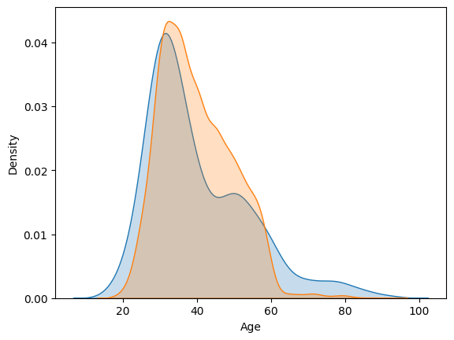

```python
sns.kdeplot(df[df['y_binary'] == 1]['age'], label = 'Subscribed', shade = True)
sns.kdeplot(df[df['y_binary'] == 0]['age'], label = 'Not Subscribed', shade = True)
plt.xlabel('Age')
plt.show()
```

#### 4. The 'month' and 'day_of_the_week' columns are combined with the year '2010' in this code to generate a new 'date' column, which is then formatted in a datetime manner. The code then groups the responses by date and filters the dataset to only contain "yes" responses in the "y" column. A line plot that displays the number of subscriptions over time is created to highlight how subscription patterns change over the course of the chosen year.This helps in understanding when and how often subscriptions occurred.

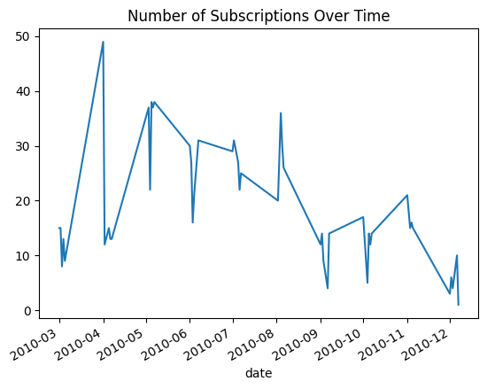

```python
df['date'] = pd.to_datetime(df['month'] + ' ' + df['day_of_week'] + ' ' + '2010')
df[df['y'] == 'yes'].groupby('date').size().plot(title='Number of Subscriptions Over Time')
plt.show()
```

```python
df.iloc[0]
```

```
age                                             42
job                                  self-employed
marital                                    married
education                        university.degree
default                                         no
housing                                         no
month                                          may
day_of_week                                    wed
duration                                       518
campaign                                         2
pdays                                          999
previous                                         0
poutcome                               nonexistent
emp.var.rate                                   1.1
cons.price.idx                              93.994
cons.conf.idx                                -36.4
euribor3m                                    4.858
nr.employed                                 5191.0
y                                               no
Age Groups                             Middle-Aged
Contact Duration Categories                   Long
y_binary                                         0
date                           2010-05-05 00:00:00
Name: 4882, dtype: object
```

# 6. Cluster Analysis

# Step-by-step hierarchical clustering:

```python
# data-points for testing the algorithm
data_points = [[35, 420, 3, 60, 2, 0.8, 94.0, -37.0, 4.5, 5200.0, 1],
               [50, 600, 1, 180, 4, -1.0, 93.2, -40.0, 3.0, 5000.0, 0],
               [28, 300, 2, 120, 1, 0.5, 94.5, -35.0, 4.2, 5250.0, 1],
               [38, 480, 4, 90, 3, -2.0, 92.5, -41.0, 3.5, 5100.0, 0],
               [45, 350, 1, 150, 2, -1.5, 93.8, -38.0, 3.8, 5150.0, 1]]
# making it a numpy array
data_points = [np.array(point) for point in data_points]
```

### Using External Libraries:

```python
from sklearn.cluster import AgglomerativeClustering
desired_clusters = 4

# Agglomerative Clustering
model = AgglomerativeClustering(n_clusters=desired_clusters)
model.fit(data_points)
cluster_labels = model.labels_
cluster_data = {cluster: [] for cluster in range(desired_clusters)}

# assigning clusters to each data-point
for i, label in enumerate(cluster_labels):
  cluster_data[label].append(data_points[i])

# printing datapoints with each cluster
for cluster, data_points in cluster_data.items():
  print(f'Cluster {cluster}:')
  for data_point in data_points:
      print(data_point)
```

```
Cluster 0:
[ 2.80e+01  3.00e+02  2.00e+00  1.20e+02  1.00e+00  5.00e-01  9.45e+01
 -3.50e+01  4.20e+00  5.25e+03  1.00e+00]
[ 4.50e+01  3.50e+02  1.00e+00  1.50e+02  2.00e+00 -1.50e+00  9.38e+01
 -3.80e+01  3.80e+00  5.15e+03  1.00e+00]
Cluster 1:
[ 5.00e+01  6.00e+02  1.00e+00  1.80e+02  4.00e+00 -1.00e+00  9.32e+01
 -4.00e+01  3.00e+00  5.00e+03  0.00e+00]
Cluster 2:
[ 3.80e+01  4.80e+02  4.00e+00  9.00e+01  3.00e+00 -2.00e+00  9.25e+01
 -4.10e+01  3.50e+00  5.10e+03  0.00e+00]
Cluster 3:
[ 3.5e+01  4.2e+02  3.0e+00  6.0e+01  2.0e+00  8.0e-01  9.4e+01 -3.7e+01
  4.5e+00  5.2e+03  1.0e+00]
```

#### Built-in Approach (Agglomeration Method):

- In the built-in approach, the hierarchical clustering algorithm automatically merged data points into clusters based on their similarities.
- Four distinct clusters were formed, they are as follows:

  ```
  Cluster 0
  Cluster 1
  Cluster 2
  Cluster 3
  ```

- Each cluster contains data points that are similar to each other.
- The output shows the data points within each cluster and their features also match. For example, Cluster 0 has data points with features age, job, duration, etc.

### Manual Approach (Without using any external libraries):

```python
# Euclidean distance calculation
def distance(a, b):
  return np.sqrt(np.sum((a - b) ** 2))
```

```python
# data points
data_points = [[35, 420, 3, 60, 2, 0.8, 94.0, -37.0, 4.5, 5200.0, 1],
               [50, 600, 1, 180, 4, -1.0, 93.2, -40.0, 3.0, 5000.0, 0],
               [28, 300, 2, 120, 1, 0.5, 94.5, -35.0, 4.2, 5250.0, 1],
               [38, 480, 4, 90, 3, -2.0, 92.5, -41.0, 3.5, 5100.0, 0],
               [45, 350, 1, 150, 2, -1.5, 93.8, -38.0, 3.8, 5150.0, 1]]
```

```python
# number of clusters
desired_clusters = 4
```

```python
# making it a numpy array
data_points = [np.array(point) for point in data_points]
clusters = [np.array([point]) for point in data_points]
```

```python
# hierarchical clustering
while len(clusters) > desired_clusters:
  min_distance = float('inf')
  merge_indices = (-1, -1)

  # finding the two closest clusters
  for i in range(len(clusters)):
    for j in range(i + 1, len(clusters)):
      cluster_i = clusters[i]
      cluster_j = clusters[j]
      d = distance(cluster_i.mean(axis=0), cluster_j.mean(axis=0))
      print(f'Distance between cluster {i} and cluster {j}: {d}')

      if d < min_distance:
        min_distance = d
        merge_indices = (i, j)

  # merging the two clusters which were found
  i, j = merge_indices
  clusters[i] = np.vstack((clusters[i], clusters[j]))
  clusters.pop(j)
```

```
Distance between cluster 0 and cluster 1: 295.0408954704415
Distance between cluster 0 and cluster 2: 143.37164991726922
Distance between cluster 0 and cluster 3: 120.57814893254914
Distance between cluster 0 and cluster 4: 124.94326712552382
Distance between cluster 1 and cluster 2: 395.7592449962477
Distance between cluster 1 and cluster 3: 180.7117594402755
Distance between cluster 1 and cluster 4: 293.1471473509507
Distance between cluster 2 and cluster 3: 236.54965652057075
Distance between cluster 2 and cluster 4: 117.06686123749965
Distance between cluster 3 and cluster 4: 151.8915073333595
```

```python
# printing the clusters and the datapoints
for i, cluster in enumerate(clusters):
  print(f'Cluster {i}:')
  for j, data_point in enumerate(cluster):
    print(f'Data Point {j + 1}: {data_point}')
```

```
Cluster 0:
Data Point 1: [ 3.5e+01  4.2e+02  3.0e+00  6.0e+01  2.0e+00  8.0e-01  9.4e+01 -3.7e+01
  4.5e+00  5.2e+03  1.0e+00]
Cluster 1:
Data Point 1: [ 5.00e+01  6.00e+02  1.00e+00  1.80e+02  4.00e+00 -1.00e+00  9.32e+01
 -4.00e+01  3.00e+00  5.00e+03  0.00e+00]
Cluster 2:
Data Point 1: [ 2.80e+01  3.00e+02  2.00e+00  1.20e+02  1.00e+00  5.00e-01  9.45e+01
 -3.50e+01  4.20e+00  5.25e+03  1.00e+00]
Data Point 2: [ 4.50e+01  3.50e+02  1.00e+00  1.50e+02  2.00e+00 -1.50e+00  9.38e+01
 -3.80e+01  3.80e+00  5.15e+03  1.00e+00]
Cluster 3:
Data Point 1: [ 3.80e+01  4.80e+02  4.00e+00  9.00e+01  3.00e+00 -2.00e+00  9.25e+01
 -4.10e+01  3.50e+00  5.10e+03  0.00e+00]
```

#### Manual Approach (Agglomeration Method Without Built-in Methods):

- In the manual approach, hierarchical clustering using the agglomeration method was performed step-by-step without any of the built-in functions.
- The hierarchical clustering calculated the distance between all pairs of clusters and merged the two closest clusters with each other until the desired number of clusters were formed.
- The output displays the distances between clusters and the final clusters which were formed.
- The two approaches achieved the same clustering result, but the manual approach had calculated the distances and merging clusters step-by-step.

# 7. Dendrogram

```python
# selecting numerical columns for clustering
numerical_cols = df.select_dtypes(include=[float, int])
```

```python
# hierarchical clustering
linkage_matrix = linkage(numerical_cols, method = 'ward')
```

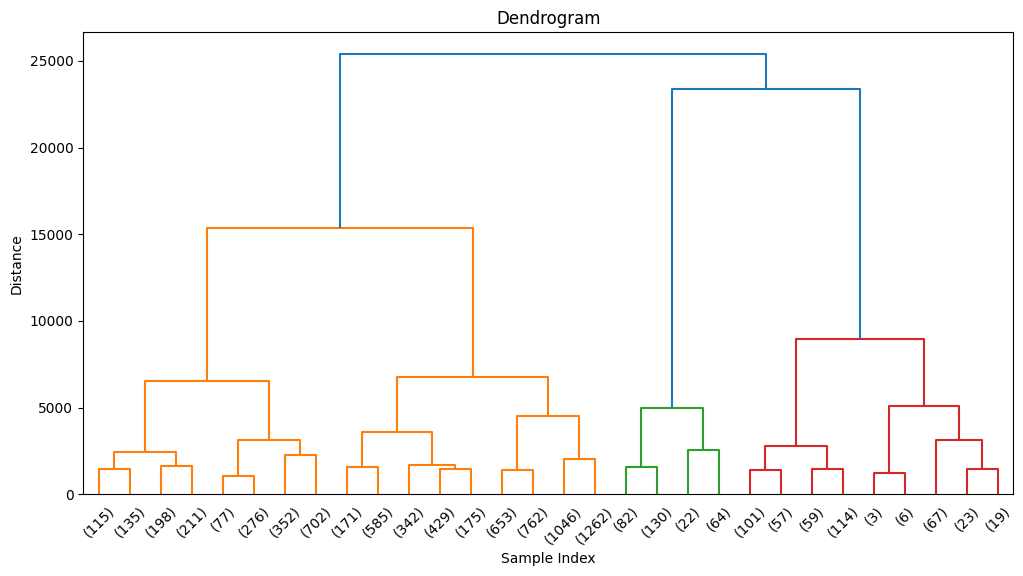

```python
# plotting the dendrogram
plt.figure(figsize = (12, 6))
dendrogram(linkage_matrix, truncate_mode = 'lastp', p = 30)
plt.title('Dendrogram')
plt.xlabel('Sample Index')
plt.ylabel('Distance')
plt.show()
```

### **Observations:**

```python
# cutting the dendrogram into 4 clusters and assign them to each datapoint
num_clusters = 4
clusters = fcluster(linkage_matrix, num_clusters, criterion = 'maxclust')
df['clusters'] = clusters
```

```python
df.head(10)
```

|  | age | job | marital | education | default | housing | month | day_of_week | duration | campaign | ... | cons.price.idx | cons.conf.idx | euribor3m | nr.employed | y | Age Groups | Contact Duration Categories | y_binary | date | clusters |
| --- | --- | --- | --- | --- | --- | --- | --- | --- | --- | --- | --- | --- | --- | --- | --- | --- | --- | --- | --- | --- | --- |
| 4882 | 42 | self-employed | married | university.degree | no | no | may | wed | 518 | 2 | ... | 93.994 | -36.4 | 4.858 | 5191.0 | no | Middle-Aged | Long | 0 | 2010-05-05 | 1 |
| 13155 | 33 | self-employed | married | university.degree | no | yes | jul | wed | 99 | 2 | ... | 93.918 | -42.7 | 4.962 | 5228.1 | no | Middle-Aged | Short | 0 | 2010-07-07 | 2 |
| 27566 | 54 | admin. | divorced | high.school | no | no | nov | fri | 639 | 2 | ... | 93.200 | -42.0 | 4.021 | 5195.8 | no | Senior | Long | 0 | 2010-11-05 | 1 |
| 18195 | 36 | technician | married | high.school | no | no | jul | wed | 1165 | 4 | ... | 93.918 | -42.7 | 4.963 | 5228.1 | no | Middle-Aged | Long | 0 | 2010-07-07 | 4 |
| 8027 | 33 | admin. | married | high.school | no | yes | jun | mon | 111 | 3 | ... | 94.465 | -41.8 | 4.865 | 5228.1 | no | Middle-Aged | Short | 0 | 2010-06-07 | 2 |
| 34314 | 26 | student | single | unknown | no | yes | may | thu | 306 | 1 | ... | 92.893 | -46.2 | 1.266 | 5099.1 | no | Young | Long | 0 | 2010-05-06 | 1 |
| 25485 | 36 | technician | married | university.degree | no | no | nov | wed | 221 | 4 | ... | 93.200 | -42.0 | 4.120 | 5195.8 | no | Middle-Aged | Medium | 0 | 2010-11-03 | 2 |
| 37752 | 34 | unemployed | single | professional.course | no | no | aug | fri | 531 | 2 | ... | 92.201 | -31.4 | 0.849 | 5076.2 | yes | Middle-Aged | Long | 1 | 2010-08-06 | 3 |
| 6822 | 25 | services | married | high.school | no | yes | may | wed | 452 | 2 | ... | 93.994 | -36.4 | 4.857 | 5191.0 | no | Young | Long | 0 | 2010-05-05 | 1 |
| 19375 | 36 | self-employed | married | basic.4y | unknown | yes | aug | wed | 175 | 4 | ... | 93.444 | -36.1 | 4.967 | 5228.1 | no | Middle-Aged | Short | 0 | 2010-08-04 | 2 |

10 rows × 24 columns

```python
cluster_labels = df['clusters']
numerical_columns = df.select_dtypes(include=[float, int])
cluster_stats = pd.DataFrame(columns = ['cluster', 'Feature', 'Mean', 'Median'])

# iterating through each cluster to calculate the mean and median
for cluster in range(1, cluster_labels.max() + 1):
  for column in numerical_columns:
    cluster_data = df[cluster_labels == cluster]
    mean_value = cluster_data[column].mean()
    median_value = cluster_data[column].median()
    cluster_stats = cluster_stats.append({'cluster': cluster, 'Feature': column, 'Mean': mean_value, 'Median': median_value}, ignore_index=True)
```

```python
cluster_stats.head(10)
```

|  | cluster | Feature | Mean | Median |
| --- | --- | --- | --- | --- |
| 0 | 1 | age | 39.959826 | 38.000 |
| 1 | 1 | duration | 412.496612 | 381.000 |
| 2 | 1 | campaign | 2.320426 | 2.000 |
| 3 | 1 | pdays | 999.000000 | 999.000 |
| 4 | 1 | previous | 0.099226 | 0.000 |
| 5 | 1 | emp.var.rate | 0.185721 | 1.100 |
| 6 | 1 | cons.price.idx | 93.585940 | 93.918 |
| 7 | 1 | cons.conf.idx | -40.286157 | -41.800 |
| 8 | 1 | euribor3m | 3.758871 | 4.857 |
| 9 | 1 | nr.employed | 5172.579429 | 5191.000 |

```python
df.columns
```

```
Index(['age', 'job', 'marital', 'education', 'default', 'housing', 'month',
       'day_of_week', 'duration', 'campaign', 'pdays', 'previous', 'poutcome',
       'emp.var.rate', 'cons.price.idx', 'cons.conf.idx', 'euribor3m',
       'nr.employed', 'y', 'Age Groups', 'Contact Duration Categories',
       'y_binary', 'date', 'clusters'],
      dtype='object')
```

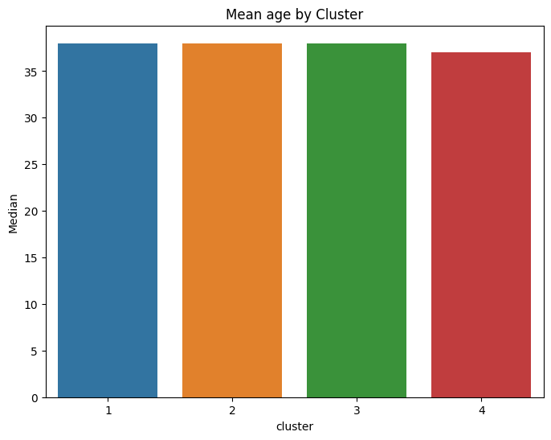

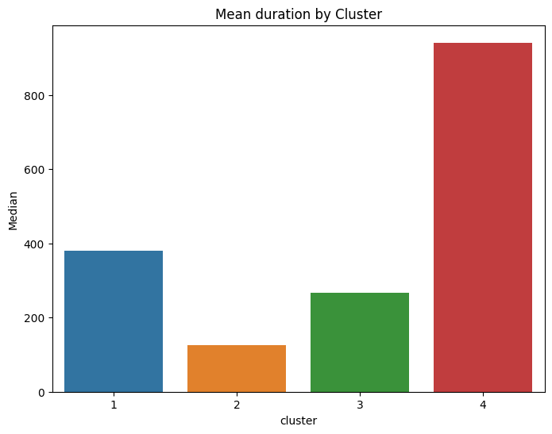

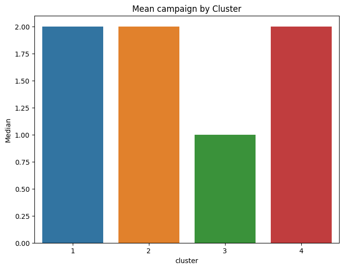

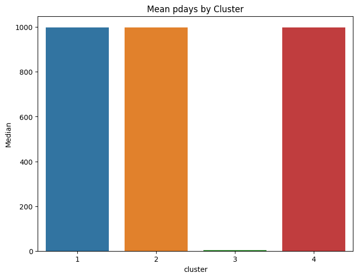

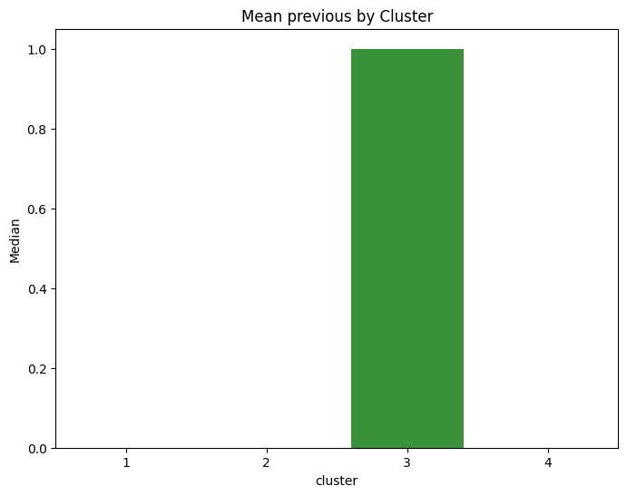

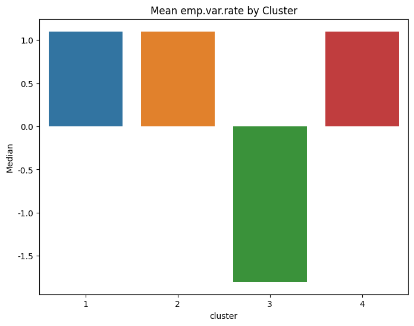

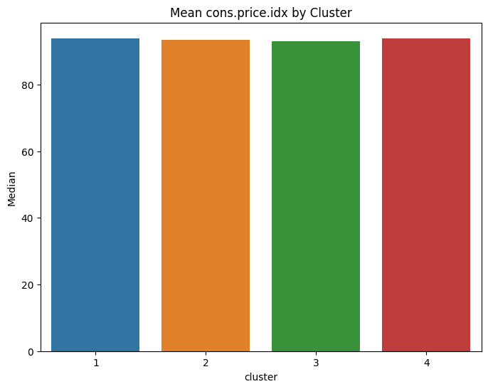

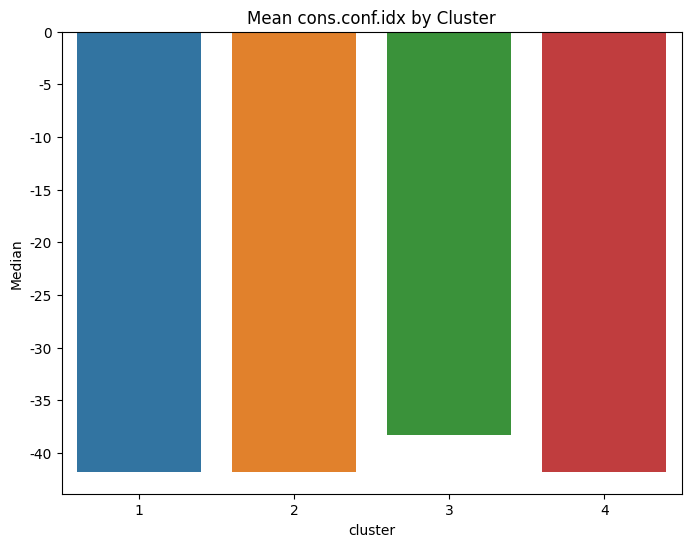

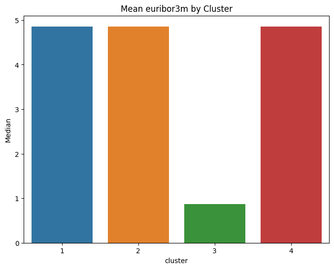

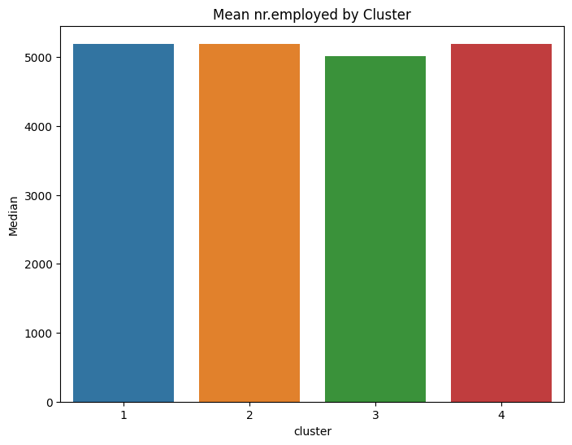

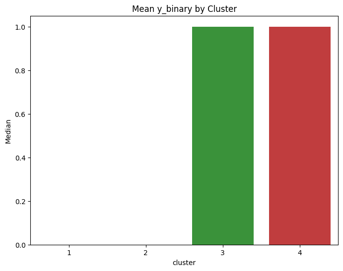

```python
numerical_features = ['age', 'duration', 'campaign', 'pdays', 'previous', 'emp.var.rate', 'cons.price.idx', 'cons.conf.idx', 'euribor3m', 'nr.employed', 'y_binary']

# bar plots for each feature's mean value by cluster
for feature in numerical_features:
  plt.figure(figsize = (8, 6))
  sns.barplot(x = 'cluster', y = 'Median', data = cluster_stats[cluster_stats['Feature'] == feature])
  plt.title(f'Mean {feature} by Cluster')
  plt.show()
```

### **Observations:**

- It can be clearly noticed that the clusters 3 and 4 vary a lot in various features from the clusters 1 and 2.
- For the features age, cons.price.idx, cons.conf.idx and nr.employed, all the clusters have same distribution and low varience. This basically means that the clusters have very less distance between them.
- In the features duration and y_binary (dependant variable), there is a good correlation. We can declare that the 4th cluster has higher values for the duration (call duration), resulting in higher chances in choosing the subscription.
- This trend of longer duration can represent that longer calls prove to be more productive than others.

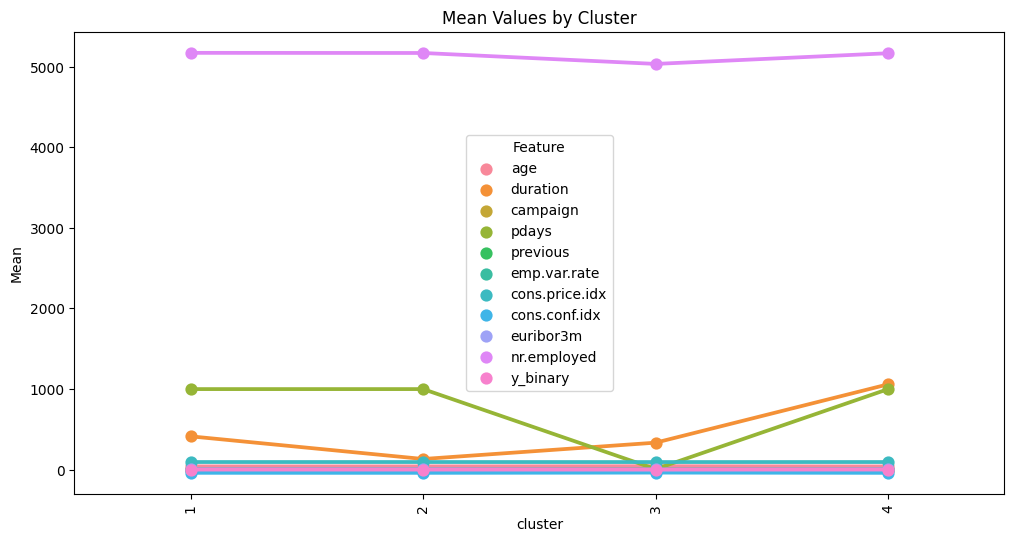

```python
# plotting a point plot to describe the distribution of all the features across the clusters
plt.figure(figsize = (12, 6))
sns.pointplot(x = 'cluster', y = 'Mean', hue = 'Feature', data = cluster_stats[cluster_stats['Feature'].isin(numerical_features)])
plt.title('Mean Values by Cluster')
plt.xticks(rotation = 90)
plt.show()
```

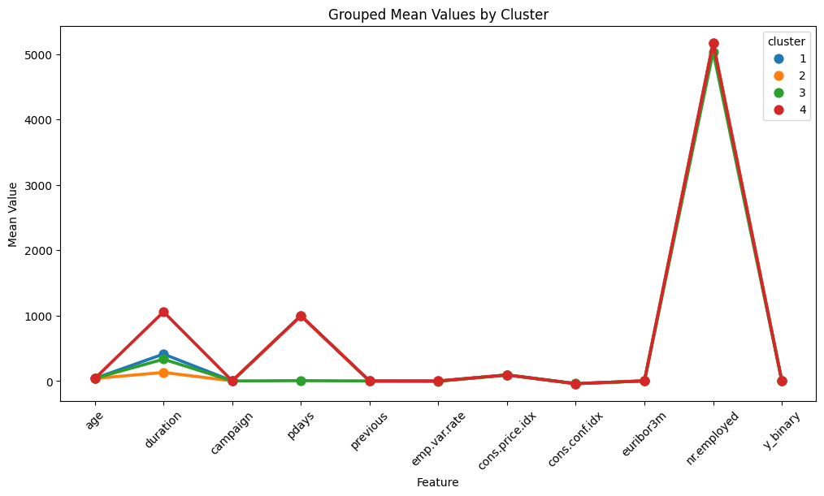

```python
# plotting a point plot to visualize the mean distribution between all the clusters
plt.figure(figsize = (12, 6))
sns.pointplot(x = 'Feature', y = 'Mean', hue = 'cluster', data = cluster_stats[cluster_stats['Feature'].isin(numerical_features)])
plt.title('Grouped Mean Values by Cluster')
plt.xlabel('Feature')
plt.ylabel('Mean Value')
plt.xticks(rotation=45)
plt.show()
```

### **Observations:**

- There is a big varience in cluster 4 with the features 'duration' and 'pdays'.
- The cluster 2 has really low values with the feature 'duration'.
- For the rest of the features such as previous, other numerical columns, the results do not have high varience.
- Yet, the dependant variable y, which displays if the customer has subscribed to the program or not is slightly higher for the clusters 3 and 4.